# Neural Network on Forest Fires

Used the resources provided and my own knowledge:  
https://datascienceplus.com/neuralnet-train-and-test-neural-networks-using-r/

## Start

### Loading Libraries and Data

```r
# load packages
suppressWarnings(library(tidyverse)) #for ggplot and dplyr
library(corrplot) #for correlation plots
library(rattle)
library(caTools)
library(neuralnet)
```

```r
setwd("C:/Users/ezhou/OneDrive - Eastside Preparatory School/Documents/Eric/2022 - 2023/1 Fall/A Data Science/Forest Fires")
forestRaw <- read.csv("forestfires.csv")
```

### Data Preprocessing

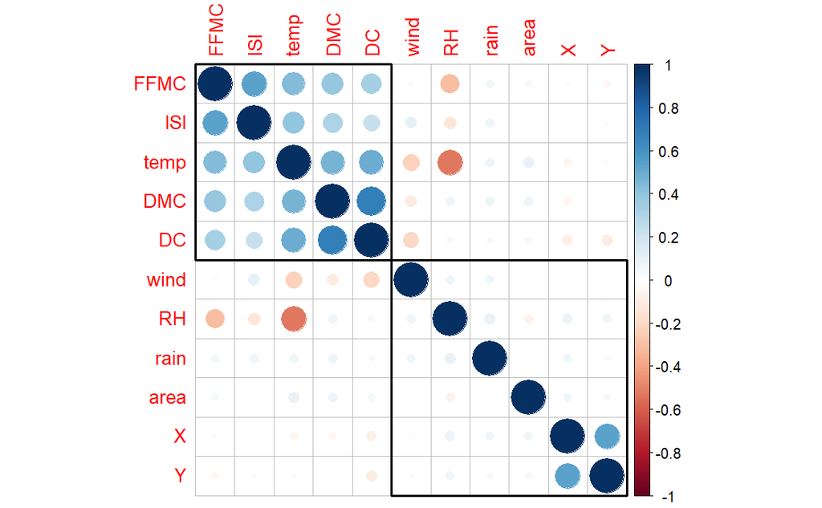

```r
# summary(forestRaw)
forestNum <- forestRaw %>% select(-month, -day)
corrs <- cor(forestNum)
corrplot(corrs, order = 'hclust', addrect = 2)
```

```r
# RMSE function
myRMSE <- function(pred, obs) {
  return(sqrt(mean((pred - obs) ^ 2, na.rm = TRUE)))
}

# Max-Min Normalization
normalize <- function(x) {
 return ((x - min(x)) / (max(x) - min(x)))
}

# Denormalizing
denormalize <- function(x, y) {
  return (y * (max(x) - min(x)) + min(x))
}
```

```r
forestNum <- forestNum %>% mutate(logArea = log(area+1))
forestNum <- forestNum %>% select(-area)
# head(forestNum)
maxmindf <- as.data.frame(lapply(forestNum, normalize))
# summary(forestNum)
```

## Neural Networks

Neural Networks were originally created to replicate human brain functions with layers of nodes that are connected. The input layer has one node for each normalized feature, going through the layers multiplying by weights and adding biases. During training, the weights and biases are tuned to through backward propogation (aka a lot of math) to try to fit the data as good as possible.

### Splitting Data

```r
set.seed(49301) # keeping the same seed as the other file
ind <- sample.split(Y=maxmindf, SplitRatio=0.8)
trainData <- maxmindf[ind,]
testData <- maxmindf[-ind,]
# head(trainData)
```

### Training NN

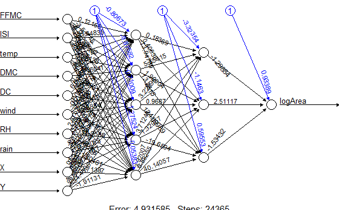

```r
start <- Sys.time()
nn <- neuralnet(logArea ~ FFMC + ISI + temp + DMC + DC + wind + RH + rain + X + Y, data=trainData, hidden=c(5, 3), linear.output=TRUE, threshold=0.01)
# nn$result.matrix
plot(nn)
```

```r
end <- Sys.time()
(time <- end - start)
```

```
Time difference of 15.11852 secs
```

Ran pretty slowly, took ~15 seconds to train.

### Checking results

```r
predicted=denormalize(forestNum$logArea, predict(nn, testData))
actual=denormalize(forestNum$logArea, testData$logArea)
myRMSE(predicted, actual)
```

```
[1] 1.265845
```

Without tuning, the RMSE is currently 1.265845, but I hope I can reduce it by a lot.